# Study 3b

## (1) Description of Data

The posted data for this study consists of 1 compiled, deidentified data file. This data file does not include data from an additional 79 respondents either because they did not complete the study, they completed the study more than once, or they nominated inappropriate or nongoal-relevant identities (e.g., “evil,” “sentient bag of meat”) or two identities that were very similar to each other (e.g., “Caucasian American” and “White American”).

## (2) Descriptive Statistics

**Total *N*:** 196

**Sensitivity analysis:** This sample provided a statistical power of .80 to detect effects of *f*<sup>2</sup> >= 0.04.

**Percentage by gender:**

```
## gender
## female   male   <NA>
##     95    101      0
```

*M*s and *SD*s:

```
##             n  mean    sd
## Age       196 31.93 11.41
## Integrate 196  4.51  1.22
## rfa       189  0.23  0.98
## rfapro    191  5.39  1.03
## rfapre    193  5.15  1.01
## rfb       183  0.24  0.96
## rfbpro    189  5.22  1.03
## rfbpre    190  4.97  1.10
## rfq       186  0.47  0.98
## rfqpro    192  3.51  0.66
## rfqpre    190  3.02  0.80
```

**Alphas:**

- **Identity-specific motivation-A promotion:** 0.8
- **Identity-specific motivation-A prevention:** 0.65
- **Identity-specific motivation-B promotion:** 0.75
- **Identity-specific motivation-B prevention:** 0.66
- **RFQ promotion:** 0.7
- **RFQ prevention:** 0.75

## (3) Correlations

**Correlations:**

```
##             lower     r upper      p  df
## rfa-rfb      0.24  0.37  0.49 0.0000 174
## rfa-rfq     -0.04  0.11  0.25 0.1433 178
## rfb-rfq     -0.03  0.12  0.26 0.1076 174
## rfdif-Intgr -0.27 -0.13  0.02 0.0972 174
```

## (4) Main Analyses

### Regressing on identity-specific motivation-A on Identity-specific motivation-B, integration, and their interaction

**Main effects:**

```
##
## Call:
## lm(formula = rfa ~ rfb_c + integration_c)
##
## Residuals:
##     Min      1Q  Median      3Q     Max
## -3.4158 -0.4590 -0.0920  0.5186  2.3289
##
## Coefficients:
##               Estimate Std. Error t value Pr(>|t|)
## (Intercept)    0.19613    0.06845   2.865  0.00468 **
## rfb_c          0.37309    0.07148   5.219  5.1e-07 ***
## integration_c -0.01299    0.05778  -0.225  0.82247
## ---
## Signif. codes:  0 '***' 0.001 '**' 0.01 '*' 0.05 '.' 0.1 ' ' 1
##
## Residual standard error: 0.9075 on 173 degrees of freedom
##   (20 observations deleted due to missingness)
## Multiple R-squared:  0.1378, Adjusted R-squared:  0.1279
## F-statistic: 13.83 on 2 and 173 DF,  p-value: 2.683e-06
```

**Main effects *CI*s:**

```
##               2.5 % 97.5 %
## (Intercept)    0.06   0.33
## rfb_c          0.23   0.51
## integration_c -0.13   0.10
```

**Omnibus test estimates:**

```
##
## Call:
## lm(formula = rfa ~ rfb_c * integration_c)
##
## Residuals:
##     Min      1Q  Median      3Q     Max
## -3.2430 -0.4366 -0.0805  0.5027  2.2758
##
## Coefficients:
##                      Estimate Std. Error t value Pr(>|t|)
## (Intercept)          0.171793   0.068821   2.496   0.0135 *
## rfb_c                0.367552   0.070867   5.187 5.97e-07 ***
## integration_c       -0.004425   0.057395  -0.077   0.9386
## rfb_c:integration_c  0.124873   0.060384   2.068   0.0401 *
## ---
## Signif. codes:  0 '***' 0.001 '**' 0.01 '*' 0.05 '.' 0.1 ' ' 1
##
## Residual standard error: 0.899 on 172 degrees of freedom
##   (20 observations deleted due to missingness)
## Multiple R-squared:  0.1588, Adjusted R-squared:  0.1441
## F-statistic: 10.82 on 3 and 172 DF,  p-value: 1.507e-06
```

**Omnibus test *CI*s:**

```
##                     2.5 % 97.5 %
## (Intercept)          0.04   0.31
## rfb_c                0.23   0.51
## integration_c       -0.12   0.11
## rfb_c:integration_c  0.01   0.24
```

*f*<sup>2</sup> value (effect size) for interaction term: 0.025

**Simple slopes:**

```
##
## ** Estimated points of rfa  **
##
##                            Low rfb_c (-1 SD) High rfb_c (+1 SD)
## Low integration_c (-1 SD)            -0.0366             0.3961
## High integration_c (+1 SD)           -0.3360             0.6817
##
##
##
## ** Simple Slopes analysis ( df= 172 ) **
##
##                            simple slope standard error t-value p.value
## Low integration_c (-1 SD)         0.222          0.102    2.19    0.03 *
## High integration_c (+1 SD)        0.523          0.101    5.16  <2e-16 ***
## ---
## Signif. codes:  0 '***' 0.001 '**' 0.01 '*' 0.05 '.' 0.1 ' ' 1
##
##
##
## ** Bauer & Curran 95% CI **
##
##               lower CI upper CI
## integration_c  -57.387  -1.2723
```

**CIs among those with low identity integration:** 0.02, 0.42

**CIs among those with high identity integration:** 0.32, 0.72

### Regressing on identity-specific motivation-B on Identity-specific motivation-A, integration, and their interaction

**Main effects:**

```
##
## Call:
## lm(formula = rfb ~ rfa_c + integration_c)
##
## Residuals:
##      Min       1Q   Median       3Q      Max
## -2.10255 -0.64410 -0.02312  0.54221  2.68430
##
## Coefficients:
##               Estimate Std. Error t value Pr(>|t|)
## (Intercept)    0.26260    0.06770   3.879 0.000149 ***
## rfa_c          0.36463    0.06986   5.219  5.1e-07 ***
## integration_c  0.11995    0.05640   2.127 0.034864 *
## ---
## Signif. codes:  0 '***' 0.001 '**' 0.01 '*' 0.05 '.' 0.1 ' ' 1
##
## Residual standard error: 0.8971 on 173 degrees of freedom
##   (20 observations deleted due to missingness)
## Multiple R-squared:  0.1596, Adjusted R-squared:  0.1498
## F-statistic: 16.42 on 2 and 173 DF,  p-value: 2.952e-07
```

**Main effects *CI*s:**

```
##               2.5 % 97.5 %
## (Intercept)    0.13   0.40
## rfa_c          0.23   0.50
## integration_c  0.01   0.23
```

**Omnibus test estimates:**

```
##
## Call:
## lm(formula = rfb ~ rfa_c * integration_c)
##
## Residuals:
##      Min       1Q   Median       3Q      Max
## -2.12730 -0.67305  0.00013  0.51393  2.58297
##
## Coefficients:
##                     Estimate Std. Error t value Pr(>|t|)
## (Intercept)          0.25736    0.06742   3.817 0.000188 ***
## rfa_c                0.35572    0.06970   5.104 8.76e-07 ***
## integration_c        0.12246    0.05613   2.182 0.030478 *
## rfa_c:integration_c  0.09437    0.05621   1.679 0.095015 .
## ---
## Signif. codes:  0 '***' 0.001 '**' 0.01 '*' 0.05 '.' 0.1 ' ' 1
##
## Residual standard error: 0.8925 on 172 degrees of freedom
##   (20 observations deleted due to missingness)
## Multiple R-squared:  0.1731, Adjusted R-squared:  0.1587
## F-statistic:    12 on 3 and 172 DF,  p-value: 3.573e-07
```

**Omnibus test *CI*s:**

```
##                     2.5 % 97.5 %
## (Intercept)          0.12   0.39
## rfa_c                0.22   0.49
## integration_c        0.01   0.23
## rfa_c:integration_c -0.02   0.21
```

*f*<sup>2</sup> value (effect size) for interaction term: 0.016

**Simple slopes:**

```
##
## ** Estimated points of rfb  **
##
##                            Low rfa_c (-1 SD) High rfa_c (+1 SD)
## Low integration_c (-1 SD)            -0.1311             0.3470
## High integration_c (+1 SD)           -0.0635             0.8561
##
##
##
## ** Simple Slopes analysis ( df= 172 ) **
##
##                            simple slope standard error t-value p.value
## Low integration_c (-1 SD)        0.2460         0.0991    2.48   0.014 *
## High integration_c (+1 SD)       0.4732         0.0949    4.98  <2e-16 ***
## ---
## Signif. codes:  0 '***' 0.001 '**' 0.01 '*' 0.05 '.' 0.1 ' ' 1
##
##
##
## ** Bauer & Curran 95% CI **
##
##               lower CI upper CI
## integration_c   -1.455   22.925
```

**CIs among those with low identity integration:** 0.05, 0.44

**CIs among those with high identity integration:** 0.29, 0.66

## (5) Figures

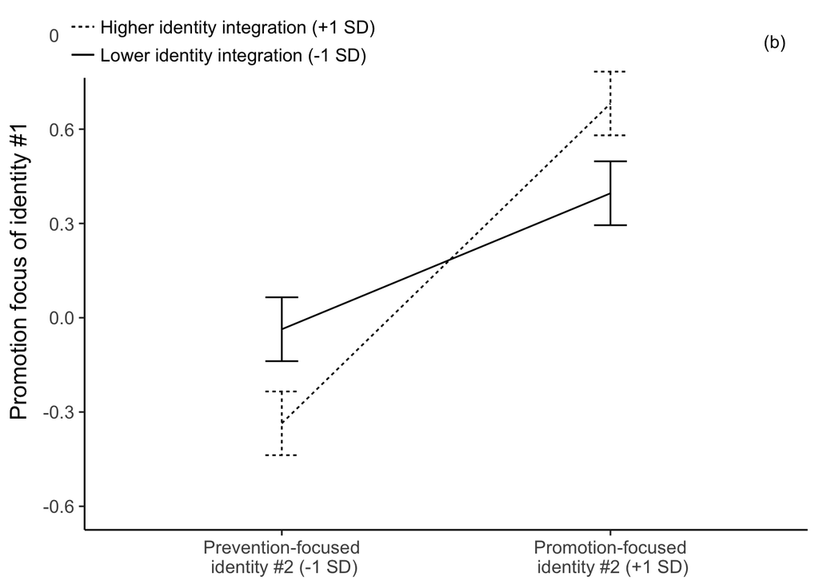